# 1

2

2024-06-24

# Do the followings in R studio using ggplot2 package with R script to knit PDF output:

## a. Create a dataset with following variables: age(10-99 years), sex(male/female), educational levels(No education/Primary/Secondary/Beyond secondary), socio-economic status(Low, Middle, High) and body mass index(14-38) with random 200 cases of each variable. Your roll number must be used to set the random seed.

```r
library(ggplot2)
library(dplyr)
library(tidyr)
set.seed(35)
data <- tibble(
  age = sample(10:99,
               size = 200,
               replace = TRUE),
  sex = sample(c("Male", "Female"),
               size = 200,
               replace = TRUE),
  educational_level = sample(c("No education", "Primary", "Secondary", "Beyond Secondary"),
                             size = 200,
                             replace = TRUE),
  socio_economic_status = sample(c("Low", "Middle", "High"),
                                 size = 200,
                                 replace = TRUE),
  body_mass_index = sample(14:38,
                           size = 200,
                           replace = TRUE)
)
```

## b. Create a scatterplot of age and body mass index variables using ggplot2 package and interpret the result carefully.

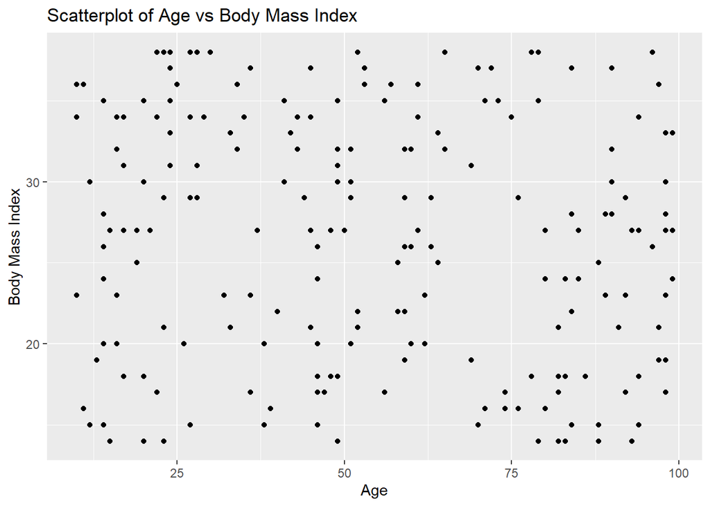

```r
ggplot(data, aes(x = age, y = body_mass_index)) +
  geom_point() +
  labs(title = "Scatterplot of Age vs Body Mass Index",
       x = "Age",
       y = "Body Mass Index")
```

Interpretation: The scatterplot shows the distribution of body mass index across different ages. There is no clear pattern or correlation observed between age and body mass index in this “data” dataset.

## c. Create classes of body mass index variable as : <18, 18-24, 25-30, 30+ and show it as pie chart using ggplot2 package and interpret it carefully.

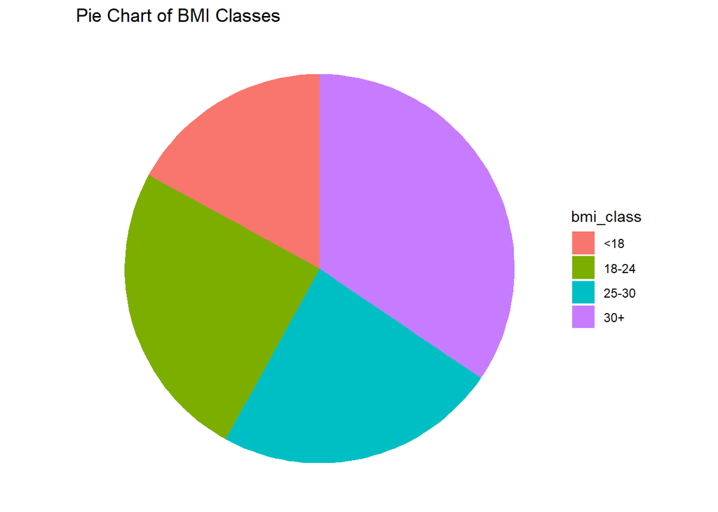

```r
data <- data %>%
  mutate(bmi_class = case_when(
    body_mass_index < 18 ~ "<18",
    body_mass_index >= 18 & body_mass_index <= 24 ~ "18-24",
    body_mass_index >= 25 & body_mass_index <= 30 ~ "25-30",
    body_mass_index > 30 ~ "30+"
  ))
bmi_class_counts <- data %>%
  count(bmi_class)
ggplot(bmi_class_counts,
       aes(x = "",
           y = n,
           fill = bmi_class)) +
  geom_bar(stat = "identity",
           width = 1) +
  coord_polar(theta = "y") +
  labs(title = "Pie Chart of BMI Classes") +
  theme_void()
```

## d. Create histogram of age variable with bin size of 15 using the ggplot2 package and interpret it carefully.

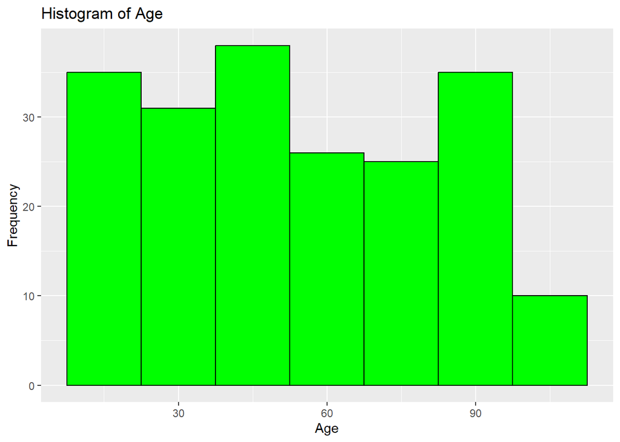

```r
ggplot(data, aes(x = age)) +
  geom_histogram(binwidth = 15, fill = "green", color = "black") +
  labs(title = "Histogram of Age",
       x = "Age",
       y = "Frequency")
```

# Do the followings in R Studio using “Arrests” dataset of car package with R script to knit PDF output:

## a. Divide the Arrests data into train and test datasets with 80:20 random splits.

```r
library(car)
set.seed(35)
data("Arrests")
arrests <- Arrests
# a. Train Test Split
# Train set = 80%
# Test set = 20%
arrests_sample <- sample(c(TRUE, FALSE), nrow(arrests),
 replace=T, prob=c(0.8, 0.2))
train_arrests <- arrests[arrests_sample,]
# train_arrests$released <- as.factor(as.numeric(train_arrests$released))
test_arrests <- arrests[!arrests_sample,]
# test_arrests$released <- as.factor(as.numeric(test_arrests$released))
```

## b. Fit a supervised logistic regression and naive Bayes classification models on train data with “released” as dependent variable and colour, age, sex, employed and citizen as independent variable.

```r
lr_model <- glm(released ~ colour+age+sex+employed+citizen,
 data=train_arrests,
 family=binomial)
vif_val <- vif(lr_model)
print(vif_val)
```

```
##   colour      age      sex employed  citizen
## 1.062239 1.025441 1.010686 1.021779 1.063224
```

VIF < 2, No multicollinearity in the data. We can fit the logistic regression model, fit Naive Bayes model.

```r
library(e1071)
library(caret)
nb_model <- naiveBayes(released ~ colour+age+sex+employed+citizen,
 data=train_arrests)
# Generate Prediction
# Generate prediction usng NB
test_pred_nb <- predict(nb_model, newdata = test_arrests)
nb_conf_mat <- confusionMatrix(as.factor(test_pred_nb), test_arrests$released)
print(nb_conf_mat)
```

```
## Confusion Matrix and Statistics
##
##           Reference
## Prediction  No Yes
##        No   19  32
##        Yes 169 904
##
##                Accuracy : 0.8212
##                  95% CI : (0.7975, 0.8432)
##     No Information Rate : 0.8327
##     P-Value [Acc > NIR] : 0.8594
##
##                   Kappa : 0.0943
##
##  Mcnemar's Test P-Value : <2e-16
##
##             Sensitivity : 0.10106
##             Specificity : 0.96581
##          Pos Pred Value : 0.37255
##          Neg Pred Value : 0.84250
##              Prevalence : 0.16726
##          Detection Rate : 0.01690
##    Detection Prevalence : 0.04537
##       Balanced Accuracy : 0.53344
##
##        'Positive' Class : No
##
```

```r
# Logistic Regerssion Model
pred <- predict(lr_model, test_arrests, type="response")
pred_tm <- as.factor(as.numeric(ifelse(pred>0.5, 1, 0)))
levels(pred_tm) <- levels(test_arrests$released)
lr_conf_mat <- confusionMatrix(pred_tm, test_arrests$released)
print(lr_conf_mat)
```

```
## Confusion Matrix and Statistics
##
##           Reference
## Prediction  No Yes
##        No    1   5
##        Yes 187 931
##
##                Accuracy : 0.8292
##                  95% CI : (0.8059, 0.8507)
##     No Information Rate : 0.8327
##     P-Value [Acc > NIR] : 0.6433
##
##                   Kappa : 0
##
##  Mcnemar's Test P-Value : <2e-16
##
##             Sensitivity : 0.0053191
##             Specificity : 0.9946581
##          Pos Pred Value : 0.1666667
##          Neg Pred Value : 0.8327370
##              Prevalence : 0.1672598
##          Detection Rate : 0.0008897
##    Detection Prevalence : 0.0053381
##       Balanced Accuracy : 0.4999886
##
##        'Positive' Class : No
##
```

```r
# Accuracy of Logistc Regression is Higher, so Logistic Regression is better.
```

# Do as follows using given dataset of 10 US cities in R studio with R script:

```r
city_distances <- matrix(c(
0, 587, 1212, 701, 1936, 604, 748, 2139, 2182, 543,
587, 0, 920, 940, 1745, 1188, 713, 1858, 1737, 597,
1212, 920, 0, 879, 831, 1726, 1611, 1949, 2204, 1494,
701, 940, 879, 0, 1374, 968, 1420, 1645, 1891, 1220,
1936, 1745, 831, 1374, 0, 2339, 2451, 347, 2734, 2300,
604, 1188, 1726, 968, 2339, 0, 1092, 2594, 2408, 923,
748, 713, 1611, 1420, 2451, 1092, 0, 2571, 678, 205,
2139, 1858, 1949, 1645, 347, 2594, 2571, 0, 678, 2442,
2182, 1737, 2204, 1891, 2734, 2408, 678, 678, 0, 2329,
543, 597, 1494, 1220, 2300, 923, 205, 2442, 2329, 0
), nrow = 10, byrow = TRUE)
# Assign row and column names
city_names <- c("Atlanta", "Chicago", "Denver", "Houston", "Los Angeles", "Miami",
"New York", "San Francisco", "Seattle", "Washington D.C.")
rownames(city_distances) <- city_names
colnames(city_distances) <- city_names
```

## a. Get dissimilarity distance as city.dissimilarity object.

```r
city.dissimilarity <- as.dist(city_distances)
```

## b. Fit a classical multidimensional model using the city.dissimilarity object.

```r
# Fit the classical MDS model
mds_model <- cmdscale(city.dissimilarity, eig = TRUE, k = 2)
mds_coords <- mds_model$points
print(mds_coords)
```

```
##                       [,1]        [,2]
## Atlanta         -616.46326  -277.03319
## Chicago         -288.61063   -22.16151
## Denver           202.61148  -672.61019
## Houston           14.25242  -335.54496
## Los Angeles     1225.78174 -1033.78934
## Miami           -968.45797  -264.31832
## New York        -845.50822   757.66327
## San Francisco   1645.58380   339.92746
## Seattle          563.12009  1646.43854
## Washington D.C. -932.30945  -138.57175
```

## c. Get the summary of the model and interpret it carefully.

```r
summary(mds_model)
```

```
##        Length Class  Mode
## points 20     -none- numeric
## eig    10     -none- numeric
## x       0     -none- NULL
## ac      1     -none- numeric
## GOF     2     -none- numeric
```

## d. Get the bi-plot of the model and interpret it carefully.

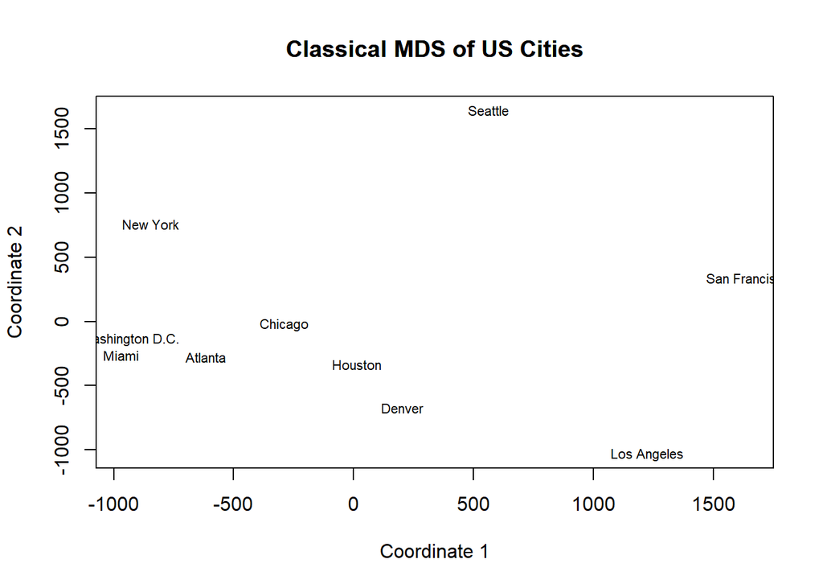

```r
# Set up the plot area
plot(mds_coords, type = "n", xlab = "Coordinate 1", ylab = "Coordinate 2", main = "Classical MDS of US Cities")
text(mds_coords, labels = city_names, cex = 0.7)
title("Classical MDS of US Cities")
```

```r
#Interpretation : It shows the distance of the cities with dissimilarities.
```

# Use the first four variables of the “iris” data and do as follows with R script to knit PDF output:

```r
# Load necessary libraries
library(datasets)
library(ggplot2)
library(cluster)
library(dendextend)
# Load the iris dataset
data("iris")
iris_data <- iris[, 1:4]
# Compute the distance matrix
dist_matrix <- dist(iris_data)
```

## a. Fit a hierarchical clustering model using single linkage and get the dendogram for this model.

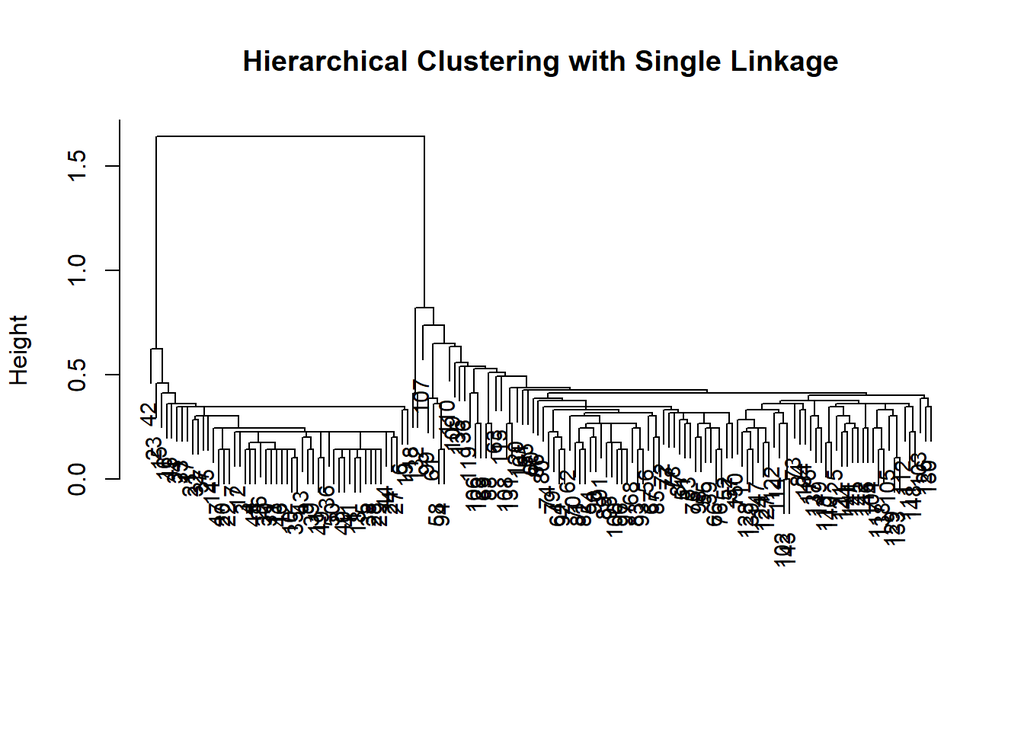

```r
# Hierarchical clustering using single linkage
hc_single <- hclust(dist_matrix, method = "single")
plot(hc_single, main = "Hierarchical Clustering with Single Linkage", xlab = "", sub = "", cex = 0.9)
```

```r
# Calculate cophenetic correlation coefficients
coph_single <- cor(dist_matrix, cophenetic(hc_single))
# Print cophenetic correlation coefficients
cat("Cophenetic Correlation Coefficient for Single Linkage:", coph_single, "\n")
```

```
## Cophenetic Correlation Coefficient for Single Linkage: 0.8638787
```

## b. Fit a hierarchical clustering model using complete linkage and get the dendogram for this model.

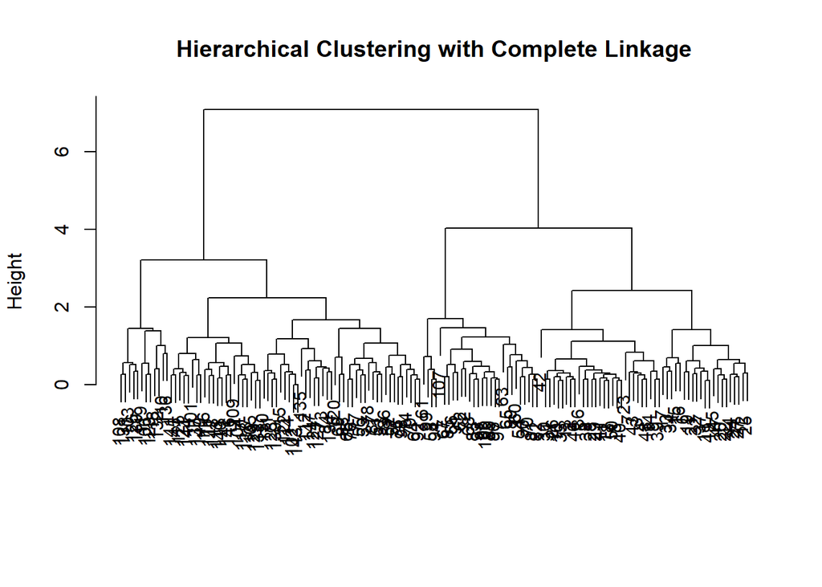

```r
# Hierarchical clustering using complete linkage
hc_complete <- hclust(dist_matrix, method = "complete")
plot(hc_complete,
     main = "Hierarchical Clustering with Complete Linkage",
     xlab = "",
     sub = "",
     cex = 0.9)
```

```r
# Calculate cophenetic correlation coefficients
coph_complete <- cor(dist_matrix, cophenetic(hc_complete))
# Print cophenetic correlation coefficients
cat("Cophenetic Correlation Coefficient for Complete Linkage:", coph_complete, "\n")
```

```
## Cophenetic Correlation Coefficient for Complete Linkage: 0.7269857
```

## c. Fit a hierarchical clustering model using average linkage and get the dendogram for this model.

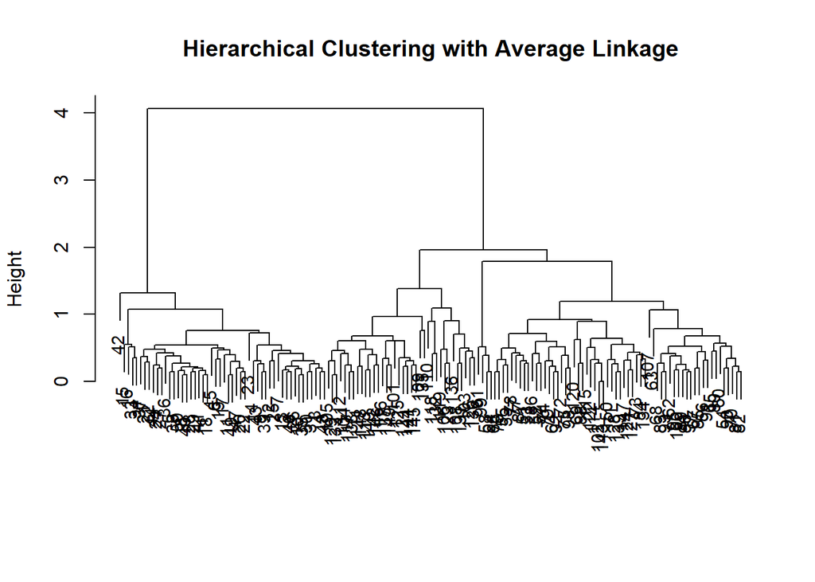

```r
# Hierarchical clustering using average linkage
hc_average <- hclust(dist_matrix, method = "average")
plot(hc_average, main = "Hierarchical Clustering with Average Linkage", xlab = "", sub = "", cex = 0.9)
```

```r
# Calculate cophenetic correlation coefficients
coph_average <- cor(dist_matrix, cophenetic(hc_average))
# Print cophenetic correlation coefficients
cat("Cophenetic Correlation Coefficient for Average Linkage:", coph_average, "\n")
```

```
## Cophenetic Correlation Coefficient for Average Linkage: 0.8769561
```

## d. Find the best hierarchical clustering model for this data and locate the number of clusters for it.

```r
# Determine the best model
best_model <- which.max(c(coph_single, coph_complete, coph_average))
if (best_model == 1) {
cat("Best model: Single Linkage\n")
best_hc <- hc_single
} else if (best_model == 2) {
cat("Best model: Complete Linkage\n")
best_hc <- hc_complete
} else {
cat("Best model: Average Linkage\n")
best_hc <- hc_average
}
```

```
## Best model: Average Linkage
```

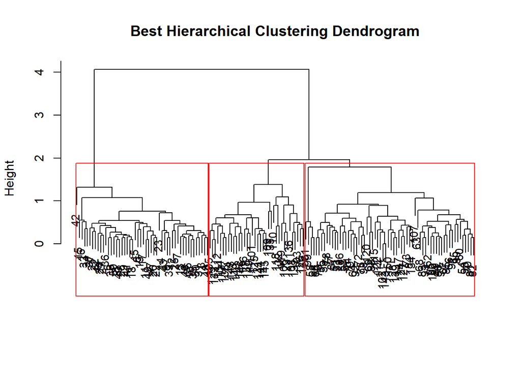

```r
# Plot the best dendrogram
plot(best_hc, main = "Best Hierarchical Clustering Dendrogram", xlab = "", sub = "", cex = 0.9)
# Determine the number of clusters
rect.hclust(best_hc, k = 3, border = "red")
```

```r
clusters <- cutree(best_hc, k = 3)
table(clusters)
```

```
## clusters
##  1  2  3
## 50 64 36
```

# Use the in-built “mtcars” data of R and do as follows in R studio with R script:

```r
# Load the mtcars dataset
data(mtcars)
```

## a. Perform the principal component analysis in the data and exact the dimensions based on components with eigenvalues >1, check it with screeplot as well and interpret the result carefully.

```r
# Principal Component Analysis (PCA)
pca <- princomp(mtcars, cor = TRUE)  # Perform PCA
eigenvalues <- pca$sdev^2  # Extract eigenvalues
eigenvalues
```

```
##     Comp.1     Comp.2     Comp.3     Comp.4     Comp.5     Comp.6     Comp.7
## 6.60840025 2.65046789 0.62719727 0.26959744 0.22345110 0.21159612 0.13526199
##     Comp.8     Comp.9    Comp.10    Comp.11
## 0.12290143 0.07704665 0.05203544 0.02204441
```

```r
# Calculate cumulative variance
cumulative_variance <- cumsum(eigenvalues) / sum(eigenvalues)
cumulative_variance
```

```
##    Comp.1    Comp.2    Comp.3    Comp.4    Comp.5    Comp.6    Comp.7    Comp.8
## 0.6007637 0.8417153 0.8987332 0.9232421 0.9435558 0.9627918 0.9750884 0.9862612
##    Comp.9   Comp.10   Comp.11
## 0.9932655 0.9979960 1.0000000
```

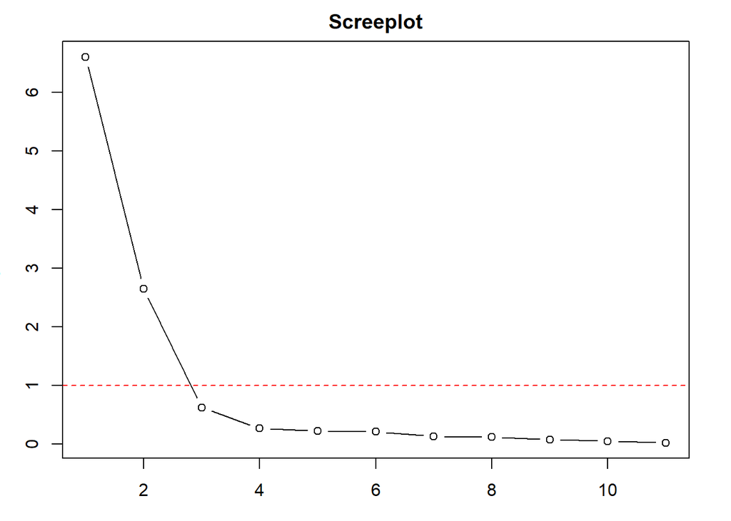

```r
# Adjust figure margins
par(mar = c(3, 3, 2, 2))
# Screeplot
plot(1:length(eigenvalues), eigenvalues, type = "b", xlab = "Component",
     ylab = "Eigenvalue", main = "Screeplot")
abline(h = 1, lty = 2, col = "red")  # Add a line at eigenvalue = 1
```

Interpretation of PCA with eigenvalues > 1: The components with eigenvalues greater than 1 indicate dimensions that explain more variance in the data than a single variable. In this case, components with eigenvalues greater than 1 can be considered meaningful. It is recommended to retain the first two components (Comp.1 and Comp.2) as they explain a significant amount of variance in the data. These components are considered meaningful dimensions that summarize the key patterns and trends present in the original variables.

## b. Perform the principal component analysis with varimax rotation in the data and exact the dimensions based on eigenvalue >1 and check it with Screeplot as well and interpret the result carefully.

```r
# Principal Component Analysis with Varimax rotation
library(psych)
pca_rotated <- principal(mtcars, nfactors = length(eigenvalues), rotate = "varimax")  # Perform PCA with varimax rotation
eigenvalues_rotated <- pca_rotated$values  # Extract eigenvalues
eigenvalues_rotated
```

```
##  [1] 6.60840025 2.65046789 0.62719727 0.26959744 0.22345110 0.21159612
##  [7] 0.13526199 0.12290143 0.07704665 0.05203544 0.02204441
```

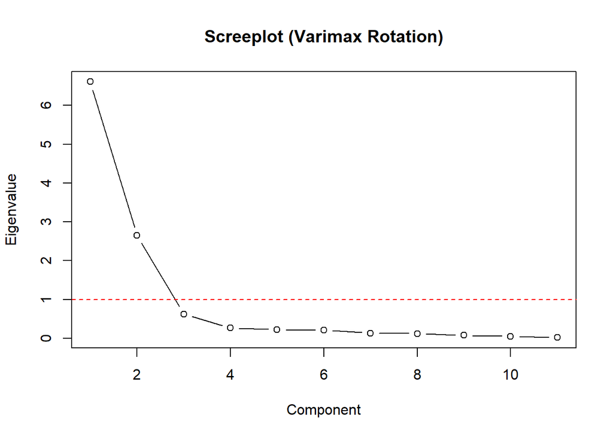

```r
# Screeplot
plot(1:length(eigenvalues_rotated), eigenvalues_rotated, type = "b", xlab = "Component", ylab = "Eigenvalue", main = "Screeplot (Varimax Rotation)")
abline(h = 1, lty = 2, col = "red")  # Add a line at eigenvalue = 1
```

Interpretation of PCA with varimax rotation and eigenvalues Similar to the previous analysis, components with eigenvalues greater than 1 are considered significant. Based on the eigenvalues greater than 1 criterion and the varimax rotation, it is recommended to retain the first two components as they explain a substantial amount of variance in the data. These components, along with the varimax rotation, provide a meaningful representation of the key patterns and relationships in the original variables, capturing the most important information while reducing the complexity and correlation among the components.

## c. Perform the classical multidimensional scaling in the data, revise the results using stress values and interpret the result carefully.

```r
# Classical Multidimensional Scaling (MDS)
library(stats)
# Perform classical multidimensional scaling
mds <- cmdscale(dist(mtcars))
mds
```

```
##                            [,1]        [,2]
## Mazda RX4            -79.596425    2.132241
## Mazda RX4 Wag        -79.598570    2.147487
## Datsun 710          -133.894096   -5.057570
## Hornet 4 Drive         8.516559   44.985630
## Hornet Sportabout    128.686342   30.817402
## Valiant              -23.220146   35.106518
## Duster 360           159.309025  -32.259197
## Merc 240D           -112.615805   39.702195
## Merc 230            -103.534591    7.513104
## Merc 280             -67.046877   -6.208536
## Merc 280C            -66.997514   -6.206387
## Merc 450SE            55.211672  -10.373509
## Merc 450SL            55.173910  -10.361893
## Merc 450SLC           55.251602  -10.370934
## Cadillac Fleetwood   242.814893   52.501758
## Lincoln Continental  236.369886   38.280788
## Chrysler Imperial    224.737944   16.111941
## Fiat 128            -172.363654    6.575522
## Honda Civic         -181.066911   17.783639
## Toyota Corolla      -179.697852    4.188212
## Toyota Corona       -121.224099   -3.345362
## Dodge Challenger      80.159386   34.983214
## AMC Javelin           67.572431   28.894067
## Camaro Z28           150.354631  -36.633575
## Pontiac Firebird     164.652522   48.239880
## Fiat X1-9           -171.897231    6.643746
## Porsche 914-2       -123.804988    2.033356
## Lotus Europa        -137.082789  -28.675647
## Ford Pantera L       159.413222  -53.318347
## Ferrari Dino         -64.762396  -62.954280
## Maserati Bora        145.361703 -139.049149
## Volvo 142E          -115.181783  -13.826313
```

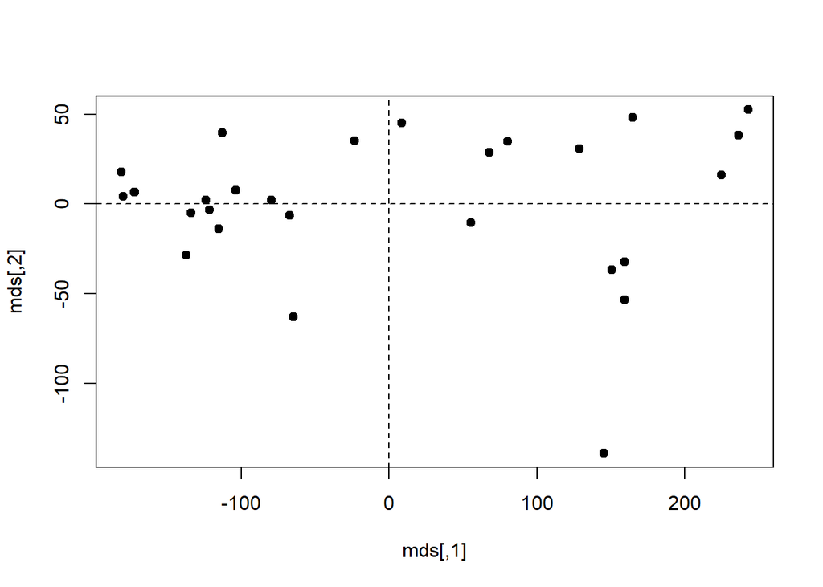

```r
plot(mds, pch = 19)
abline(h=0, v=0, lty=2)
```

```r
# Calculate stress values
dissimilarity_matrix <- dist(mtcars)  # Dissimilarity matrix of the original data
reduced_distances <- as.dist(dist(mds))  # Distances in the reduced-dimensional space
stress_values <- sqrt(sum((dissimilarity_matrix - reduced_distances)^2)) / sqrt(sum(dissimilarity_matrix^2))
stress_values
```

```
## [1] 0.001862287
```

Interpretation of MDS using stress values: The stress value obtained from the classical multidimensional scaling (MDS) analysis is 0.001862287. The stress value is a measure of the discrepancy between the distances in the reduced-dimensional space and the original dissimilarity matrix. The stress values represent the goodness-of-fit of the MDS solution. Lower stress values indicate a better representation of distances in the reduced space. To interpret the MDS results, compare stress values across different MDS solutions and choose the solution with the lowest stress value as it provides the best representation of the original distances.

## d. Perform the hierarchical cluster analysis in the data and determine the number of clusters to exact using the dendogram and cut at the various distances with justification.

```r
# Hierarchical Cluster Analysis
dist_matrix <- dist(mtcars)  # Calculate dissimilarity matrix
hclust_res <- hclust(dist_matrix, method = "complete")
hclust_res
```

```
##
## Call:
## hclust(d = dist_matrix, method = "complete")
##
## Cluster method   : complete
## Distance         : euclidean
## Number of objects: 32
```

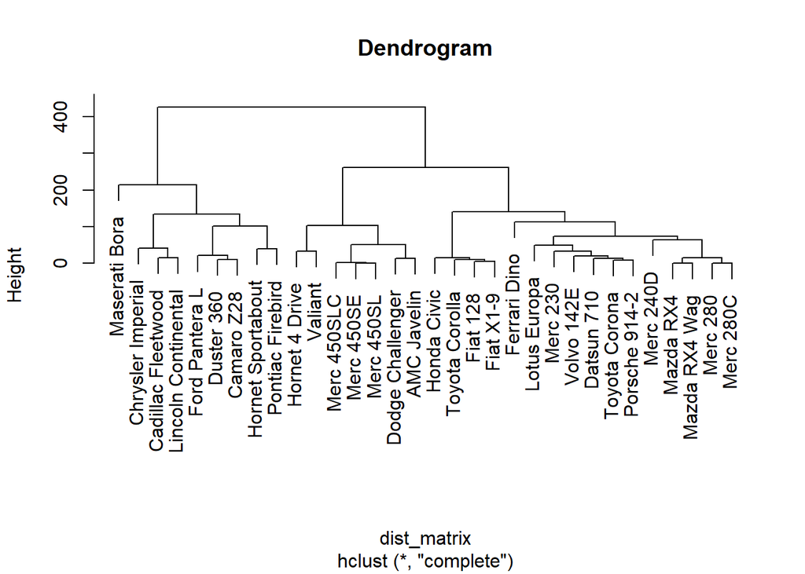

```r
# Dendrogram
plot(hclust_res, main = "Dendrogram")
```

```r
# Determine the number of clusters using the dendrogram
cut_heights <- c(100, 150, 200)  # Adjust based on dendrogram visual inspection
cut_clusters <- cutree(hclust_res, h = cut_heights)
cut_clusters
```

```
##                     100 150 200
## Mazda RX4             1   1   1
## Mazda RX4 Wag         1   1   1
## Datsun 710            1   1   1
## Hornet 4 Drive        2   2   2
## Hornet Sportabout     3   3   3
## Valiant               2   2   2
## Duster 360            4   3   3
## Merc 240D             1   1   1
## Merc 230              1   1   1
## Merc 280              1   1   1
## Merc 280C             1   1   1
## Merc 450SE            5   2   2
## Merc 450SL            5   2   2
## Merc 450SLC           5   2   2
## Cadillac Fleetwood    6   3   3
## Lincoln Continental   6   3   3
## Chrysler Imperial     6   3   3
## Fiat 128              7   1   1
## Honda Civic           7   1   1
## Toyota Corolla        7   1   1
## Toyota Corona         1   1   1
## Dodge Challenger      5   2   2
## AMC Javelin           5   2   2
## Camaro Z28            4   3   3
## Pontiac Firebird      3   3   3
## Fiat X1-9             7   1   1
## Porsche 914-2         1   1   1
## Lotus Europa          1   1   1
## Ford Pantera L        4   3   3
## Ferrari Dino          8   1   1
## Maserati Bora         9   4   4
## Volvo 142E            1   1   1
```

## e. Perform the k-means cluster analysis in the data based on the number of clusters identified using dendogram and interpret the result carefully.

```r
# 5. K-means Cluster Analysis
library(cluster)
# Perform k-means clustering based on the number of clusters identified from the dendogram
k <- 3  # Adjust based on the dendogram analysis
kmeans_res <- kmeans(mtcars, centers = k)
kmeans_res
```

```
## K-means clustering with 3 clusters of sizes 4, 17, 11
##
## Cluster means:
##        mpg      cyl     disp        hp     drat       wt     qsec         vs
## 1 13.67500 8.000000 443.0000 206.25000 3.060000 4.966000 17.56750 0.00000000
## 2 24.12353 4.705882 128.3353  97.35294 3.929412 2.573412 18.64176 0.76470588
## 3 16.19091 7.818182 311.7636 201.27273 3.277273 3.576364 16.72545 0.09090909
##          am     gear     carb
## 1 0.0000000 3.000000 3.500000
## 2 0.6470588 4.058824 2.352941
## 3 0.1818182 3.363636 3.272727
##
## Clustering vector:
##           Mazda RX4       Mazda RX4 Wag          Datsun 710      Hornet 4 Drive
##                   2                   2                   2                   3
##   Hornet Sportabout             Valiant          Duster 360           Merc 240D
##                   3                   2                   3                   2
##            Merc 230            Merc 280           Merc 280C          Merc 450SE
##                   2                   2                   2                   3
##          Merc 450SL         Merc 450SLC  Cadillac Fleetwood Lincoln Continental
##                   3                   3                   1                   1
##   Chrysler Imperial            Fiat 128         Honda Civic      Toyota Corolla
##                   1                   2                   2                   2
##       Toyota Corona    Dodge Challenger         AMC Javelin          Camaro Z28
##                   2                   3                   3                   3
##    Pontiac Firebird           Fiat X1-9       Porsche 914-2        Lotus Europa
##                   1                   2                   2                   2
##      Ford Pantera L        Ferrari Dino       Maserati Bora          Volvo 142E
##                   3                   2                   3                   2
##
## Within cluster sum of squares by cluster:
## [1]  4665.041 42877.103 56041.432
##  (between_SS / total_SS =  83.4 %)
##
## Available components:
##
## [1] "cluster"      "centers"      "totss"        "withinss"     "tot.withinss"
## [6] "betweenss"    "size"         "iter"         "ifault"
```

# Open the R or R studio software and do the followings with R script:

# a. Define integers from 1 to 15 using three different coding approaches in r.

```r
R1 <- 1:15
R2 <- seq(1,15)
R3 <- c(1,2,3,4,5,6,7,8,9,10,11,12,13,14,15)
```

# b. Define these five numbers: 1.1, 2.2, 3.3, 4.4 and 5.5 and save it as column vector N.

```r
N <- c(1.1, 2.2, 3.3, 4.4, 5.5)
matrix(N,
        ncol = 1,
        dimnames = list(NULL, "N"))
```

```
##        N
## [1,] 1.1
## [2,] 2.2
## [3,] 3.3
## [4,] 4.4
## [5,] 5.5
```

# c. Add, subtract, multiply and divide vector R from vector N and interpret the results carefully

```r
R <- 1:15
add_result <- N + R
print("Addition Result:")
```

```
## [1] "Addition Result:"
```

```r
print(add_result)
```

```
##  [1]  2.1  4.2  6.3  8.4 10.5  7.1  9.2 11.3 13.4 15.5 12.1 14.2 16.3 18.4 20.5
```

```r
sub_result <- N - R
print("Subtraction Result:")
```

```
## [1] "Subtraction Result:"
```

```r
print(sub_result)
```

```
##  [1]  0.1  0.2  0.3  0.4  0.5 -4.9 -4.8 -4.7 -4.6 -4.5 -9.9 -9.8 -9.7 -9.6 -9.5
```

```r
mul_result <- N * R
print("Multiplication Result:")
```

```
## [1] "Multiplication Result:"
```

```r
print(mul_result)
```

```
##  [1]  1.1  4.4  9.9 17.6 27.5  6.6 15.4 26.4 39.6 55.0 12.1 26.4 42.9 61.6 82.5
```

```r
div_result <- N / R
print("Division Result:")
```

```
## [1] "Division Result:"
```

```r
print(div_result)
```

```
##  [1] 1.1000000 1.1000000 1.1000000 1.1000000 1.1000000 0.1833333 0.3142857
##  [8] 0.4125000 0.4888889 0.5500000 0.1000000 0.1833333 0.2538462 0.3142857
## [15] 0.3666667
```

# d. Define a list using “This” “is” “my” “first” “programming” “in” “R” and save it as L.

```r
(L <- list(c("This","is","my","first","programming","in","R" )))
```

```
## [[1]]
## [1] "This"        "is"          "my"          "first"       "programming"
## [6] "in"          "R"
```

# e. Transform these list elements as characters of UL object.

```r
UL <- unlist(L)
print("Unlisted List (UL):")
```

```
## [1] "Unlisted List (UL):"
```

```r
print(UL)
```

```
## [1] "This"        "is"          "my"          "first"       "programming"
## [6] "in"          "R"
```

# 2. Load the “rdmTweets.rdata” file in R studio and do as follows with “tm” and “tweetR” packages:

```r
suppressWarnings(
  library(rtweet)
)
load("rdmTweets.rdata")
```

## a. Convert twitter list as data frame and assign it as “df” object.

```r
suppressWarnings(
  library(tm)
)
suppressWarnings(
  library(twitteR)
)
df <- twListToDF(rdmTweets)
```

## b. Create corpus using the “text” column of the data frame.

```r
corpus <- Corpus(VectorSource(df$text))
# c. Perform pre-processing to clean the corpus for text mining.
corpus_copy <- corpus
corpus <- tm_map(corpus,
                 content_transformer(tolower))
corpus <- tm_map(corpus,
                 removePunctuation)
corpus <- tm_map(corpus,
                 removeNumbers)
corpus <- tm_map(corpus,
                 removeWords,
                 stopwords("en"))
corpus <- tm_map(corpus,
                 stripWhitespace)
```

## c. Create term document matrix using the cleaned corpus.

```r
tdm <- TermDocumentMatrix(corpus)
```

## d. Find the most frequent terms using the term document matrix.

```r
freq_terms <- findFreqTerms(tdm)
```

## e. Find the co-occurrence of the term “r” with filter of 0.1 and above.

```r
co_occur <- findAssocs(tdm,
                       term = "r",
                       corlimit = 0.1)
head(freq_terms)
```

```
## [1] "big"             "data"            "httptcohzojaw"   "mit"
## [5] "position"        "postdocresearch"
```

```r
print(co_occur)
```

```
## $r
## numeric(0)
```

# Load the “igraph” package in R studio and do the basic SNA as follows with R scripts to:

```r
library(igraph)
```

## a. Defining g as graph object with (1,2) as its elements.

```r
g <- graph(edges = c(1, 2))
```

## b. Plot the g and interpret it carefully.

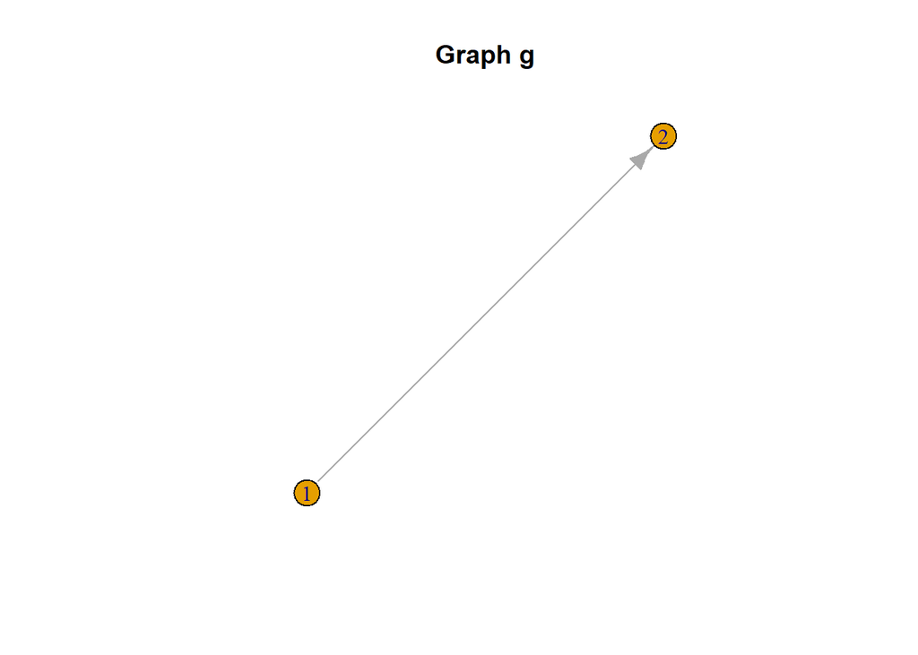

```r
plot(g,
     main = "Graph g"
     )
```

# c. Define g1 as graph object with (“S”, “R”, “R”, “G”, “G”, “S”, “S”, “G”, “A”, “R”) as its elements.

```r
g1 <- graph(edges = c("S", "R", "R", "G", "G", "S", "S", "G", "A", "R"))
```

# d. Plot g1 with node color as green, node size as 30, link color as red and link size as 5 and interpret it.

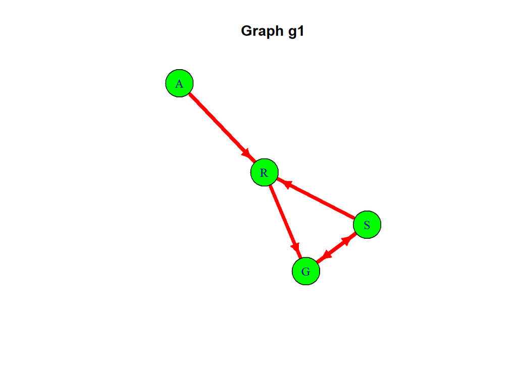

```r
plot(g1,
     vertex.color = "green",
     vertex.size = 30,
     edge.color = "red",
     edge.width = 5,
     main = "Graph g1")
```

```r
# e. Get degree, closeness and betweenness of g1 and interpret them carefully.
degree <- degree(g1)
closeness <- closeness(g1)
betweenness <- betweenness(g1)
print(degree)
```

```
## S R G A
## 3 3 3 1
```

```r
print(closeness)
```

```
##         S         R         G         A
## 0.5000000 0.3333333 0.3333333 0.1666667
```

```r
print(betweenness)
```

```
## S R G A
## 1 2 2 0
```

# Do the following in R Studio with R script so that it can be knitted as PDF:

```r
library(ggplot2)
library(gridExtra)
set.seed(35)
```

# a. Prepare a column vector of miles per gallon (mpg) variable with random range between 10 to 50 of 500 values.

```r
mpg <- runif(500,
             min = 10,
             max = 50)
```

# b. Plot histogram of this “mpg” variable and interpret it carefully.

```r
hist_mpg <- ggplot(data = data.frame(mpg),
                   aes(x = mpg))+
  geom_histogram(binwidth = 5,
                 fill = "lightblue",
                 color = "black")+
  labs(title = "Histogram of Miles Per Gallon (mpg)",
       x = "Miles Per Gallon (mpg)",
       y = "Frequency")
```